# wrangling_pokemon

Kevin Wang

16/07/2021

```r
library(tidyverse)
pokemon = readr::read_csv("./data/pokemon.csv")
## remotes::install_github("schochastics/Rokemon")
library(Rokemon)
readr::write_csv(
  x = Rokemon::pokemon %>%
    dplyr::select(pokedex_number, name,
                  type1, type2,
                  # generation, is_legendary,
                  attack, defense,
                  # hp, speed,
                  sp_attack, sp_defense
                  ),
  file = "./data/pokemon.csv")
```

## Filter

Filter is used to pick some cases or observations (rows) in the data. Here’s an example for the `pokemon` data. We will choose just the pokemons that are “grass” type (use the `type1` variable).

```r
pokemon %>% filter(type1 == "grass") %>% tally()
```

```
## # A tibble: 1 x 1
##       n
##   <int>
## 1    78
```

*Try it!* Do these exercises:

- Filter the pokemon data to pick only pokemons that are “fire” type (use the `type2` variable)
- Filter the pokemons that are more than 150 units in `attack` (HINT: you can use `>` or `<` if the variable is just made up of numbers)
- Filter the pokemon that are either “fire” in `type1` **or** “water” in `type1` (HINT: You need to use the operator `%in%` like this `%in% c("fire","water"))`
- Filter the pokemon that are “fire” in `type1` **and** “water” in `type2` (HINT: You can add additional conditions in the `filter` function by adding an extra comma like `filter(type1 == "fire", ...)`)

```r
pokemon %>% filter(type2 == "fire")
pokemon %>% filter(attack > 150)
pokemon %>% filter(type1 %in% c("fire", "water"))
pokemon %>% filter(type1 == "fire", type2 == "water")
```

## Select

Select is used to pick some variables in the data. Here’s an example for the `pokemon` data. We will select just the variables `name` and `attack`.

```r
pokemon %>% select(name, attack)
```

```
## # A tibble: 801 x 2
##    name       attack
##    <chr>       <dbl>
##  1 Bulbasaur      49
##  2 Ivysaur        62
##  3 Venusaur      100
##  4 Charmander     52
##  5 Charmeleon     64
##  6 Charizard     104
##  7 Squirtle       48
##  8 Wartortle      63
##  9 Blastoise     103
## 10 Caterpie       30
## # ... with 791 more rows
```

*Try it!* Select the variables `name`, `type1`, `attack` and `defense`.

## Arrange

`arrange` sorts the data by values in one of the columns. Here’s an example which also involves selecting a subset of variables.

```r
pokemon %>%
  select(name, attack) %>%
  arrange(desc(attack))
```

```
## # A tibble: 801 x 2
##    name      attack
##    <chr>      <dbl>
##  1 Heracross    185
##  2 Kartana      181
##  3 Groudon      180
##  4 Rayquaza     180
##  5 Garchomp     170
##  6 Banette      165
##  7 Rampardos    165
##  8 Gallade      165
##  9 Tyranitar    164
## 10 Blaziken     160
## # ... with 791 more rows
```

Note that `desc` arranges in descending order.

*Try it!* Arrange carat by price, in increasing order.

```r
pokemon %>%
  select(name, attack, defense) %>%
  arrange(desc(attack))
```

```
## # A tibble: 801 x 3
##    name      attack defense
##    <chr>      <dbl>   <dbl>
##  1 Heracross    185     115
##  2 Kartana      181     131
##  3 Groudon      180     160
##  4 Rayquaza     180     100
##  5 Garchomp     170     115
##  6 Banette      165      75
##  7 Rampardos    165      60
##  8 Gallade      165      95
##  9 Tyranitar    164     150
## 10 Blaziken     160      80
## # ... with 791 more rows
```

Arrange is mostly used to get quick views of the numbers.

## Mutate

I love the name mutate! It means to create new variables, or modify existing ones. For the pokemon dataset, we might be interested in examining the sum of both `attack` and `sp_attack`. Here’s how we can create this variable:

```r
pokemon %>%
  mutate(total_attack = attack + sp_attack)
```

```
## # A tibble: 801 x 9
##    pokedex_number name       type1 type2  attack defense sp_attack sp_defense
##             <dbl> <chr>      <chr> <chr>   <dbl>   <dbl>     <dbl>      <dbl>
##  1              1 Bulbasaur  grass poison     49      49        65         65
##  2              2 Ivysaur    grass poison     62      63        80         80
##  3              3 Venusaur   grass poison    100     123       122        120
##  4              4 Charmander fire  <NA>       52      43        60         50
##  5              5 Charmeleon fire  <NA>       64      58        80         65
##  6              6 Charizard  fire  flying    104      78       159        115
##  7              7 Squirtle   water <NA>       48      65        50         64
##  8              8 Wartortle  water <NA>       63      80        65         80
##  9              9 Blastoise  water <NA>      103     120       135        115
## 10             10 Caterpie   bug   <NA>       30      35        20         20
## # ... with 791 more rows, and 1 more variable: total_attack <dbl>
```

*Try it!* Compute a new variable called `total_defense`, as the sum of `defense` and `sp_defense`.

## Summarise

Summarise is the workhorse function. It takes columns of the data, and reduces them to single numbers. It is most useful when we want to compute statistics for our.

For the pokemons, we might be interested in computing the mean, minimum and maximum of `attack` value of all pokemons

```r
pokemon %>%
  summarise(
    min = min(attack),
    mean = mean(attack),
    max = max(attack)
  )
```

```
## # A tibble: 1 x 3
##     min  mean   max
##   <dbl> <dbl> <dbl>
## 1     5  77.9   185
```

However, the `attack` value might be dependent on the type of the pokemon, so we can compute this separately for each of the `type1` categories. Which type of pokemon has the highest average attack?

```r
pokemon %>%
  group_by(type1) %>%
  summarise(mean = mean(attack))
```

```
## # A tibble: 18 x 2
##    type1     mean
##    <chr>    <dbl>
##  1 bug       70.1
##  2 dark      87.8
##  3 dragon   106.
##  4 electric  70.8
##  5 fairy     62.1
##  6 fighting  99.2
##  7 fire      81.5
##  8 flying    66.7
##  9 ghost     72.7
## 10 grass     73.8
## 11 ground    94.8
## 12 ice       73.3
## 13 normal    75.2
## 14 poison    72.7
## 15 psychic   65.6
## 16 rock      90.7
## 17 steel     93.1
## 18 water     73.3
```

If it helps, we can use `arrange` to help us to answer this question.

```r
pokemon %>%
  group_by(type1) %>%
  summarise(mean = mean(attack)) %>%
  arrange(desc(mean))
```

```
## # A tibble: 18 x 2
##    type1     mean
##    <chr>    <dbl>
##  1 dragon   106.
##  2 fighting  99.2
##  3 ground    94.8
##  4 steel     93.1
##  5 rock      90.7
##  6 dark      87.8
##  7 fire      81.5
##  8 normal    75.2
##  9 grass     73.8
## 10 water     73.3
## 11 ice       73.3
## 12 ghost     72.7
## 13 poison    72.7
## 14 electric  70.8
## 15 bug       70.1
## 16 flying    66.7
## 17 psychic   65.6
## 18 fairy     62.1
```

# Grammar of graphics

Before we begin this section, I would like to invite you to take a look at the two plots below and tell me what do you think the (only) difference is between the two plots?

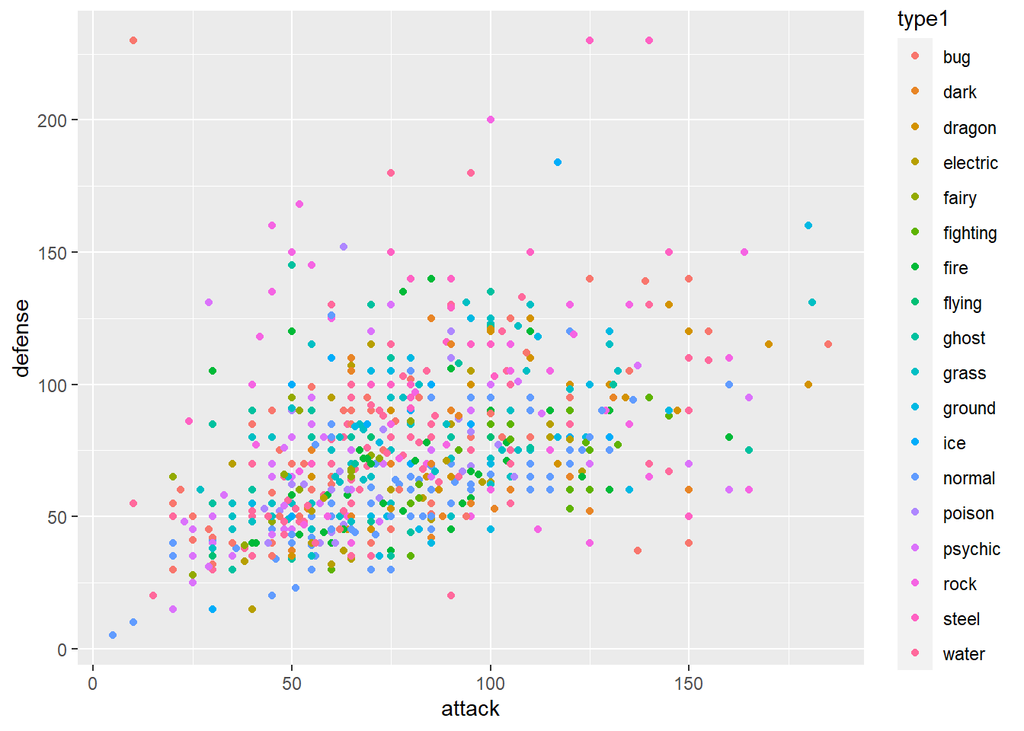

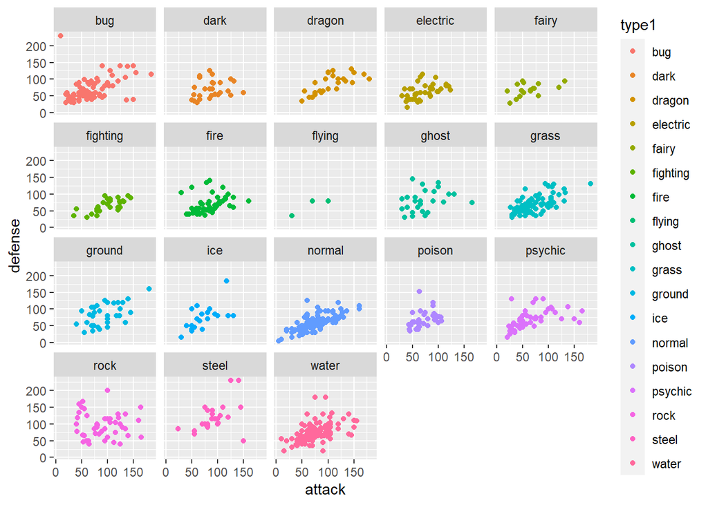

In both plots, notice that

- x-axis is `attack`
- y-axis is `defense`
- colouring variable is `type1`
- Each observation (pokemon) is a simple point

From that perspective, both plots are presenting the same information to you. However, the second plot has one extra feature, in that each type gets its own little plot, or “facet”.

We are now ready to talk about the grammar of graphics. There are hundreads of plots that statisticians can use, but we need a consistent way to describe these plots and the rules to describe these plots is like how we have grammar in English to govern how language is used.

The **grammar of graphics** is a language that maps variables into graphical elements. If you take a look at how we have described the plots above, each graphical element (x-axis, y-axis, etc) correspond to one and only one variable (`attack`, `defense`, etc). Thus, instead of uniquely naming specialist plots, like barchart, pie chart, histogram… grammar of graphics provides the description of a plot, that enables we to compare how they are similar and different. It gives us a more formal, and yes, mathematical way to make data plots.

The grammar of graphics has these major elements:

```
ggplot(data = <DATA>) +
  <GEOM_FUNCTION>(
     mapping = aes(<MAPPINGS>),
     stat = <STAT>,
     position = <POSITION>
  ) +
  <COORDINATE_FUNCTION> +
  <FACET_FUNCTION>
```

- **DATA**: This is the `data.frame` or `tibble` that you are starting from
- **MAPPINGS**: Specific details of how a variable is mapped into the plot
- **GEOM**: The graphical element to use, e.g. point, line, rectangle, density, boxplot, …
- **STAT**: A statistical calculation, if necessary, e.g. bin to make a histogram or barchart.
- **POSITION**: Some types of plots, like barcharts conventionally have small deviations in design, like stacked, side-by-side, 100%. Position enables this type of shift.
- **COORDINATE**: Most commonly we are using cartesian coordinates, but some plots benefit by putting them in polar coordinates, or even in a special map ratio, or some variables shown on a log scale.
- **FACET**: Split the data into subsets and plot separately. Good for making comparisons across groups.

The `+` operation behaves exactly like you expect: it “adds” additional graphical elements or manipulations on the plot. This is similar to how you would draw a picture in real life first by finding some contents (in our case, the data) to draw on, then deciding what should be in the picture (the geom) and finally adding on other elemenets (the mappings, e.g. colours).

Here are some examples.

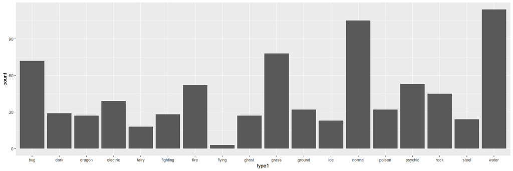

```r
ggplot(data = pokemon) +
  geom_bar(mapping = aes(x = type1))
```

This is a barchart of the types of pokemons. We can see that the “water” pokemon is the most common.

## Making scatter plot

We will now try to construct the scatter plots above. Notice how we describe the mapping between the variables is exactly how we construct the plot!

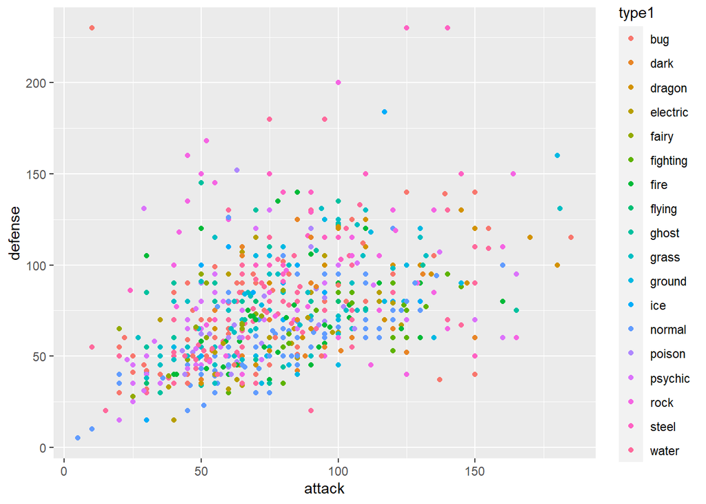

This plot doesn’t look too bad, however, one thing that we noticed was that there are a lot of types and they are overlaying on top of each other on the same plot. How would we improve over this? This is exactly why we use facets in the first example to separate out the points by types. Facetting is very easy in ggplot, it simply needs an extra line and a specification of which variable should be used as the facets.

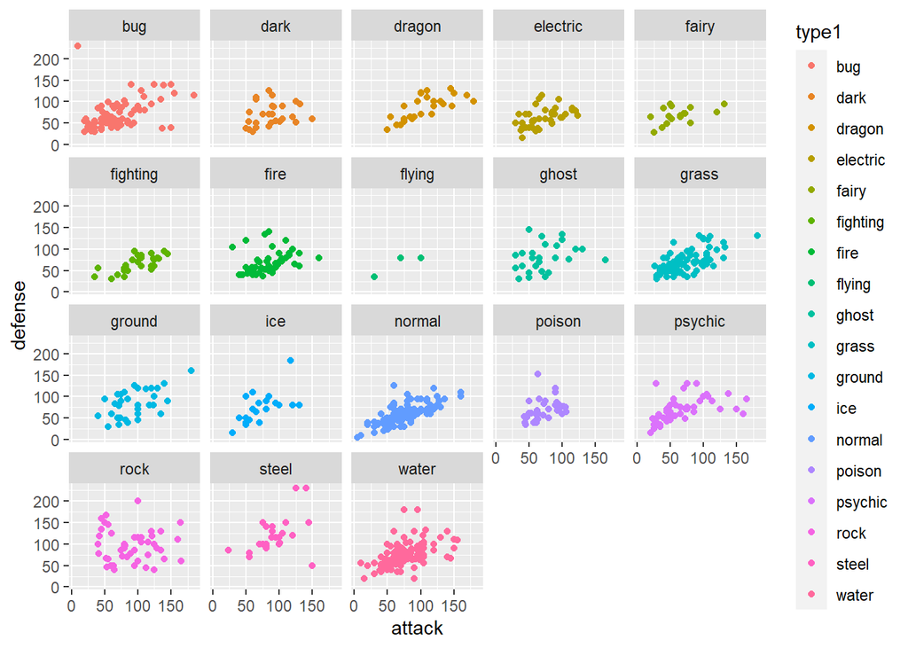

```r
ggplot(pokemon) +
  geom_point(aes(x = attack,
                 y = defense,
                 colour = type1)) +
  facet_wrap(~type1)
```

This plot is better in that we can compare the scattering of points across different types of pokemons now whereas before, our eyes are too busy trying to identify the colours. In fact, you will notice that we used the `type1` variable twice, which means that this variable appeared twice as two different visual elements - once as colour and once as facets. This is ok, but it can be redundant. Having a consistent way of describing plots allows us to detect such things and we may even decide removing `type1` as a colour variable.

**Try it:** remove the `type1` as the colouring variable in the plot above. What is the default colour of `geom_point`?

## Making a heatmap (advanced)

Have you ever thought about why would anyone use any plots? If our data is the original complete information, then why don’t we just interpret that information directly? Afterall, any plot that we make can only represent the data in limit ways because there are only limited number of visual elements we can throw onto a plot.

The key to answer this question is that, a plot should be a tool of communication of key information. Yes, a data may contain lots of information, but without summarising the data in clever ways, nothing can be interpreted because data are often huge.

Let’s see an example of this. In the `pokemon` data, there are `type1` and `type2` variables. These variables indicate the type of a certain pokemon with some pokemons having only `type1` but many pokemons has both. So what can we do to understand the total number of pokemons in each categories of `type1` and `type2`?

We could certainly tabulate these counts. But we would end up with 166 categories, which is still too much for us to understand. We can see the average or maximum of these counts, but this can be very limiting. This is where data visualisation can help us to see important patterns.

```r
poke_counts = pokemon %>%
  group_by(type1, type2) %>%
  tally()

poke_counts
```

```
## # A tibble: 166 x 3
## # Groups:   type1 [18]
##    type1 type2        n
##    <chr> <chr>    <int>
##  1 bug   electric     4
##  2 bug   fairy        2
##  3 bug   fighting     3
##  4 bug   fire         2
##  5 bug   flying      13
##  6 bug   ghost        1
##  7 bug   grass        6
##  8 bug   ground       1
##  9 bug   poison      11
## 10 bug   rock         3
## # ... with 156 more rows
```

In the plot below, we see that each number is represented as a “tile”, and the “fill” colour of the tile is represented by the number of pokemons in those combined categories of `type1` and `type2`.

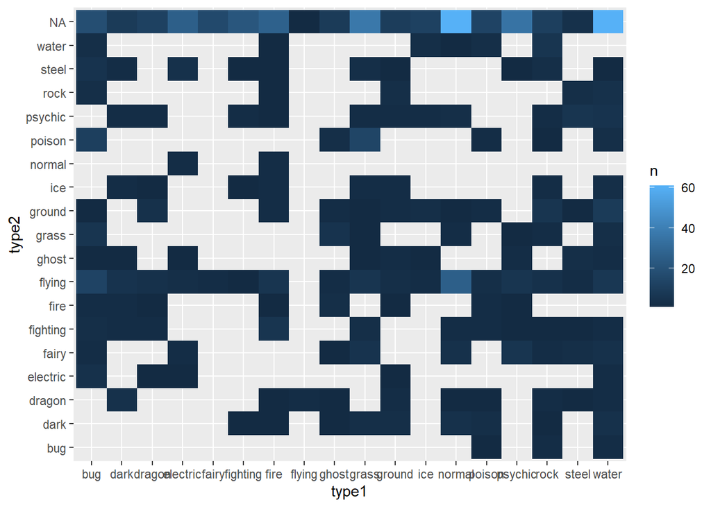

```r
poke_counts %>%
  ggplot() +
  geom_tile(aes(x = type1, y = type2,
             fill = n))
```

We can further make adjustments on the plot to make it prettier. It is not necessary to understand the code below, but you should feel free to play with the different options and layers of the ggplot to see what each element is doing.

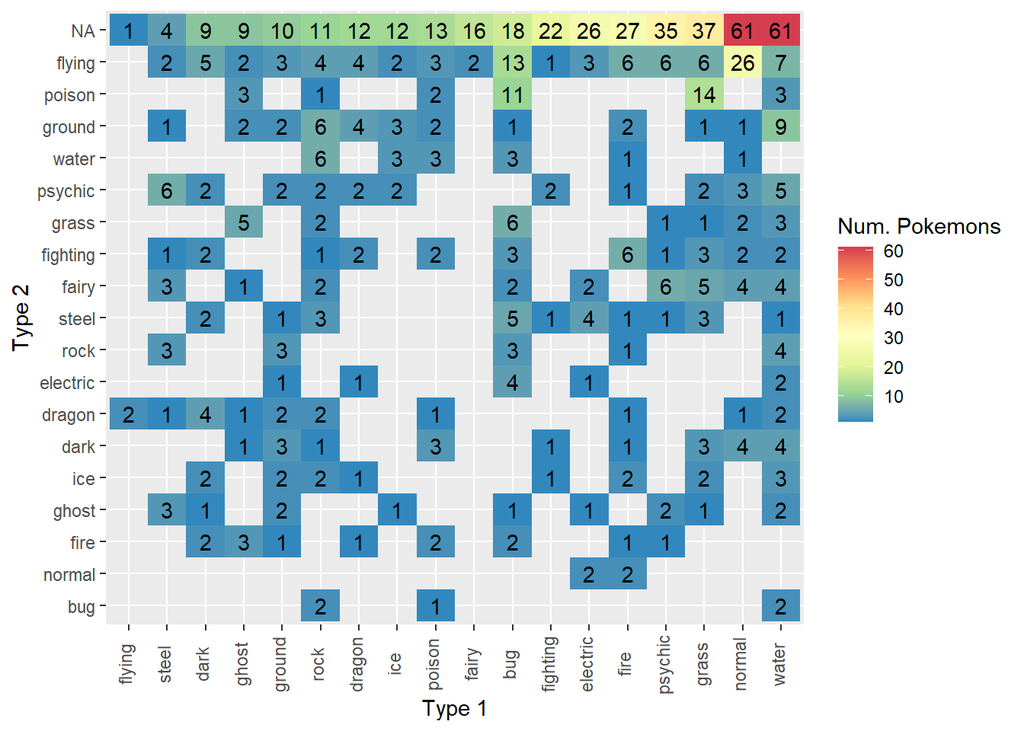

```r
poke_counts %>%
  ggplot(aes(x = fct_reorder(type1, n, .fun = max),
             y = fct_reorder(type2, n, .fun = max))) +
  geom_tile(aes(fill = n)) +
  geom_text(aes(label = n)) +
  scale_fill_distiller(palette = "Spectral",
                       breaks = c(0, 10, 20, 30, 40, 50, 60)) +
  theme(axis.text.x = element_text(angle = 90, vjust = 0.2)) +
  labs(x = "Type 1",
       y = "Type 2",
       fill = "Num. Pokemons")
```

**Try it**:

- What does `scale_fill_distiller` do? (HINT: comment this line out by adding a `#` in front of the line of code and run again)
- What does `theme(axis.text.x = ...)` do? What if you change the `angle` to 45?
- What does `labs(...)` do?
- Replace `x = fct_reorder(type1, n, .fun = max)` in the second line with just `x = type1` as we had before. What happened to the plot? Can you guess what `fct_reorder` do?